# Week 1 exercises

## Section 3.5.1

1. What happens if you facet on a continuous variable?

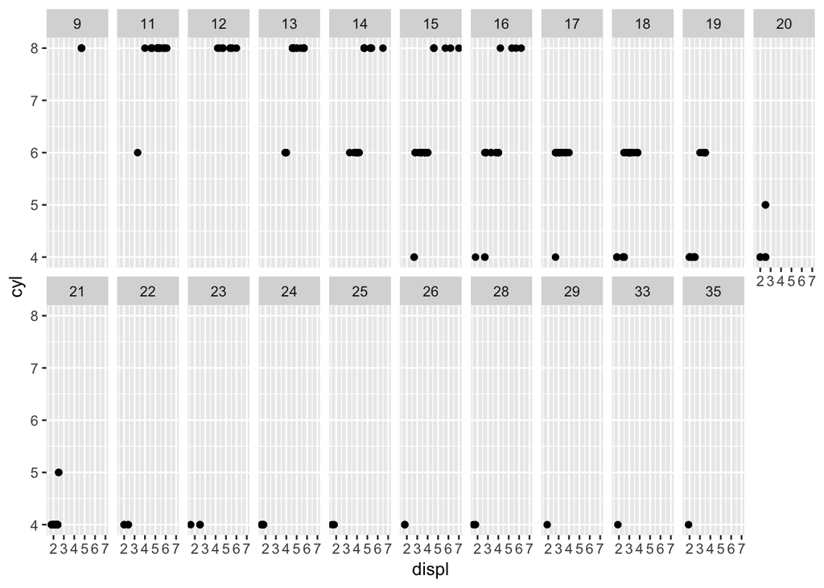

```r
ggplot(data = mpg) +
  geom_point(mapping = aes(x = displ, y = cyl)) +
  facet_wrap(~ cty, nrow = 2)
```

Way too many panels, not enough info!

3. What plots does the following code make? What does . do?

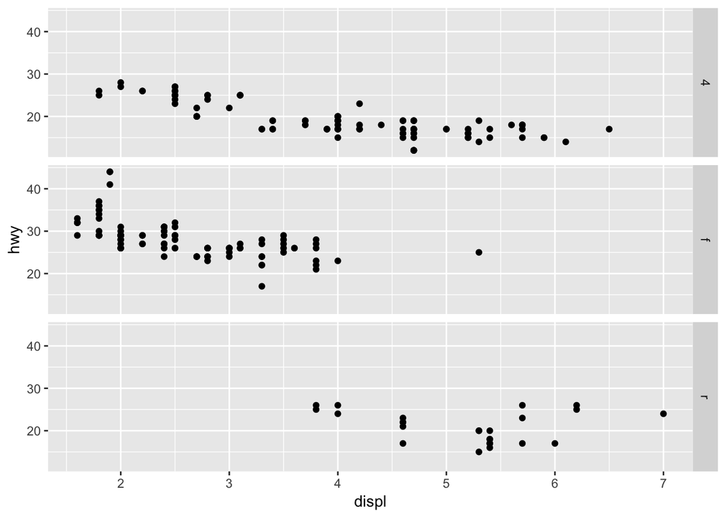

```r
ggplot(data = mpg) +
  geom_point(mapping = aes(x = displ, y = hwy)) +
  facet_grid(drv ~ .)
```

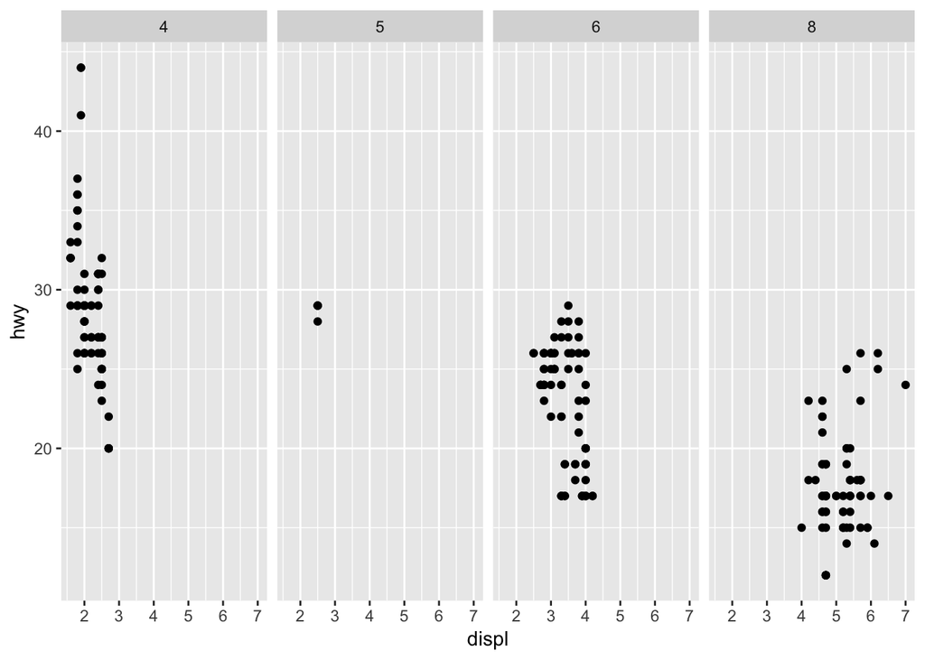

```r
ggplot(data = mpg) +
  geom_point(mapping = aes(x = displ, y = hwy)) +
  facet_grid(. ~ cyl)
```

The period stands for either row or column.

## Section 3.6.1

2. Run this code in your head and predict what the output will look like. Then, run the code in R and check your predictions.

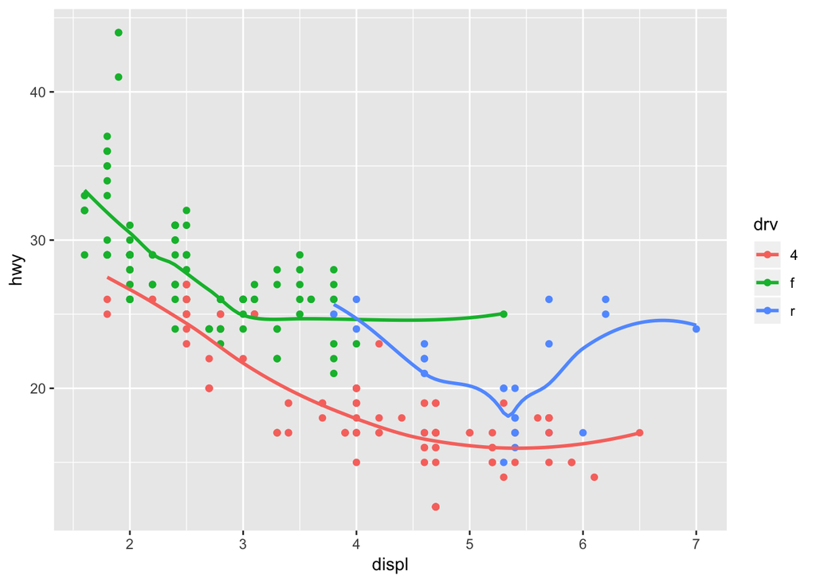

```r
ggplot(data = mpg, mapping = aes(x = displ, y = hwy, color = drv)) +
  geom_point() +
  geom_smooth(se = FALSE)
```

It is instructive to compare the above plot with the result of the code from the book:

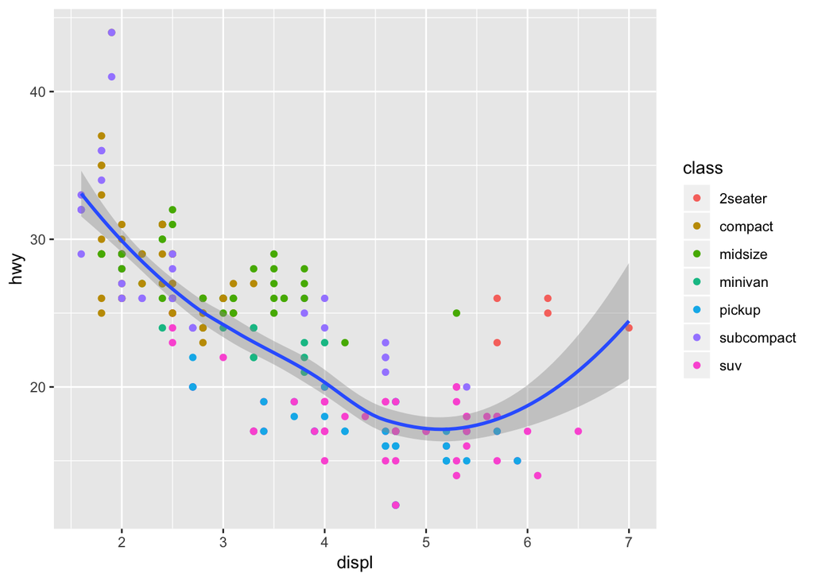

```r
ggplot(data = mpg, mapping = aes(x = displ, y = hwy)) +
  geom_point(mapping = aes(color = class)) +
  geom_smooth()
```

The difference is that geom_smooth draws different curves if the aesthetic is mapped to discrete values. In the second example, I think the reason is that the points are colored separately from the plotting, so the grouping is not passed on to geom_smooth.

4. What does the se argument to geom_smooth() do?

Shows the standard error around the fitted curve.

## Section 3.7.1

1. What is the default geom associated with stat_summary()? How could you rewrite the previous plot to use that geom function instead of the stat function?

```
## No summary function supplied, defaulting to `mean_se()
```

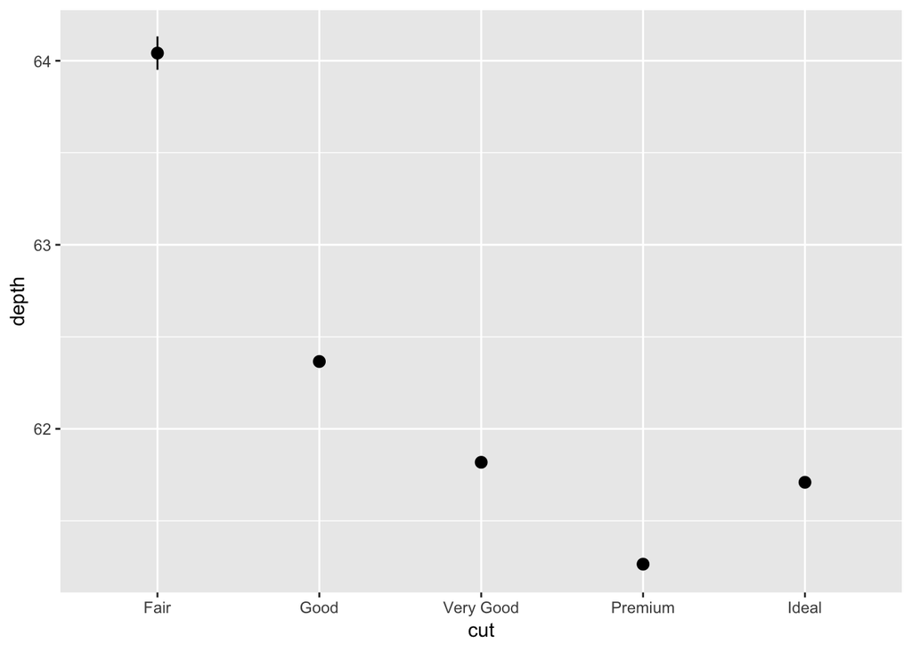

```r
ggplot(data = diamonds) +
  stat_summary(mapping = aes(x = cut, y = depth))
```

I think it uses mean_se, which just shows the mean and standard errors.

5. In our proportion bar chart, we need to set group = 1. Why? In other words what is the problem with these two graphs?

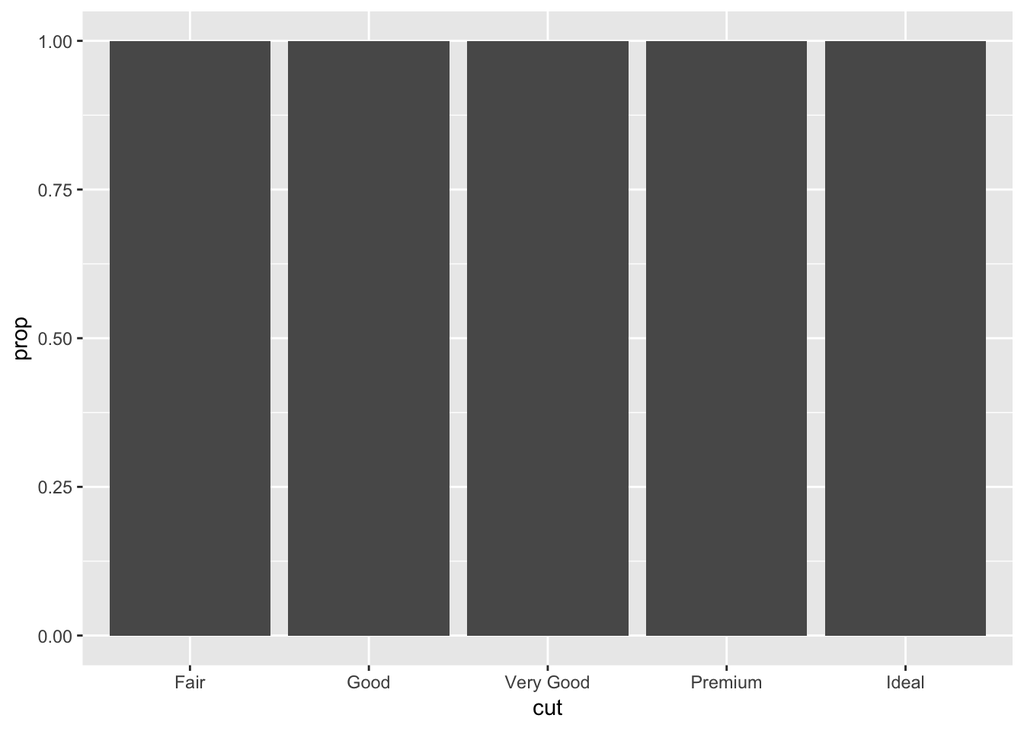

```r
ggplot(data = diamonds) +
  geom_bar(mapping = aes(x = cut, y = ..prop..))
```

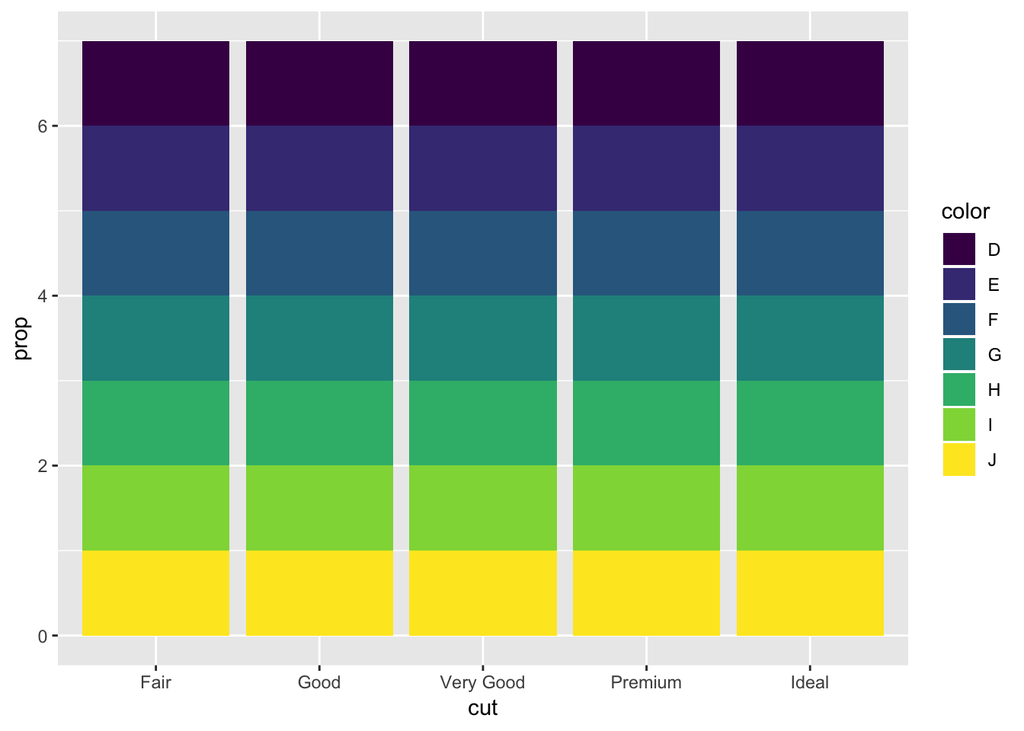

```r
ggplot(data = diamonds) +
  geom_bar(mapping = aes(x = cut, fill = color, y = ..prop..))
```

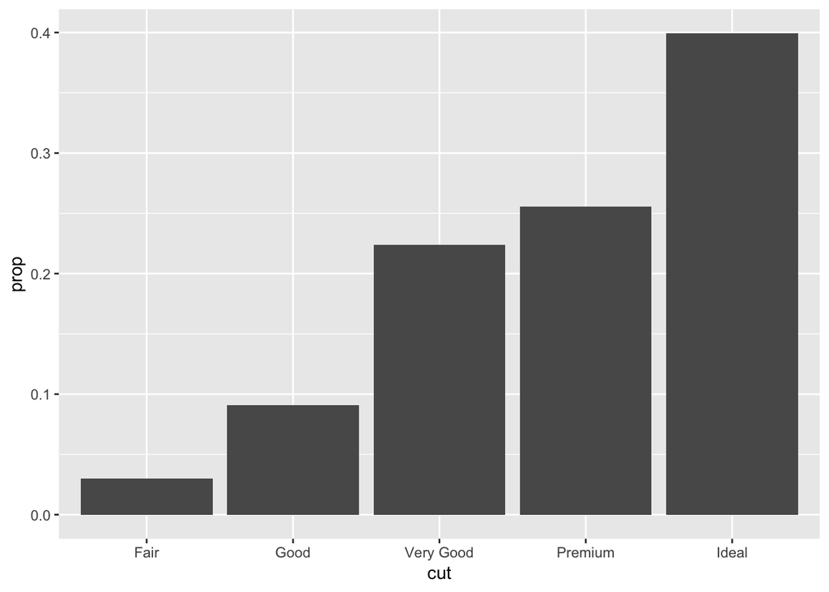

```r
ggplot(data = diamonds) +
  geom_bar(mapping = aes(x = cut, y = ..prop.., group = 1))
```

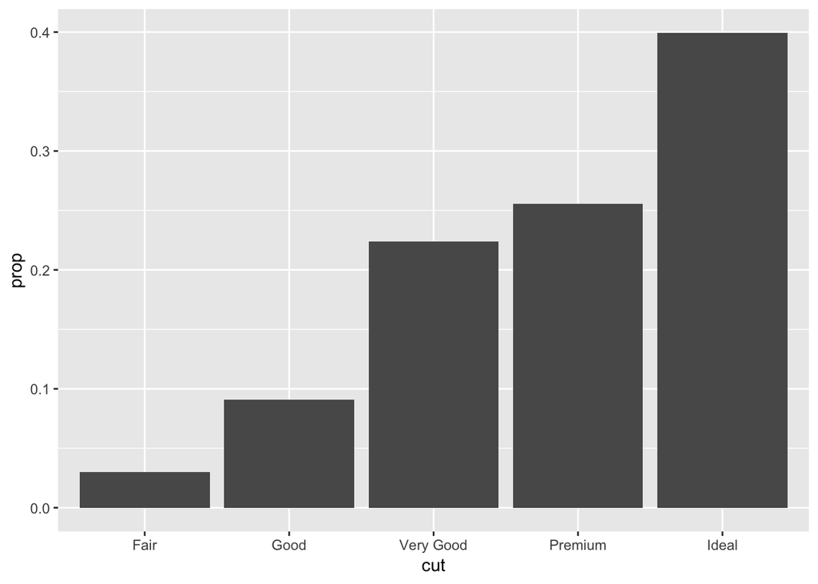

```r
ggplot(data = diamonds) +
  geom_bar(mapping = aes(x = cut, y = ..prop.., group = 1, fill = color))
```

The first line is missing group = 1, without which the proportions are not computed properly. The second script I’m not sure about, because I can’t make the fill work.